# Project: Investigate a Dataset - [No_show_appointments.csv]

- Introduction
- Data Wrangling
- Exploratory Data Analysis
- Conclusions

## Introduction

### Dataset Description

The columns in this dataset I would be wirKing with are listed below and their significance;

1.PatientId: This identifies a patient.

2.AppointmentID: this signifies each patient's appointment number.

3.Gender: This signifies each gender i.e either male or female.

4.Scheduled Day:this indicates the appointment dates scheduled for each patient.

5.Appointment day:this shows the dates for each patient

6.Age: this column 'age' shows the different age of each patients.

7.Neighbourhood: thisshows the location.

8.Scholarship: indicates if the patient is a beneficiary of the brazilian welfare program(Bolsa Familia program).

9.Hipertension:a type of disease a patient has.

10.Diabetes: a type of disease apatient has.

11.Alcoholism: a type of disease a patient has.

12.Handcap: a type of disease a patient has.

13.SMS_received:this signifies messages sent to the patient.

14.No-show :"No" indicates if the patient showed up to their appointment and "Yes" if they didn't show up to their appointments

### Question(s) for Analysis

Questions for Analysis

1. DO MORE FEMALES IN YOUNG AGE SHOW UP MORE THAN FEMALES IN OLD AGE?

2.IS GENDER AS A SINGLE VARIABLE RELATED TO PATIENT's SHOWING UP?

3.IS SCHOLARSHIP SIGNIFICANT IN DETERMINING PATIENTS SHOW UP ?

The questions above would be discussed amd answered in the exploratory data analysis and conclusoon section, moving further jupyter notebook is what i'd be using for this investigation to submit both code and report(using the markdown to mark the report in a text filev format)

Proper investigation of this dataset would requirte of packages like numpy,pandas,matplotlib,seaborn and i would be importing them as they've been installed already in my notebook

```python
# import statements for all packages used
import pandas as Pd
import numpy as np
import matplotlib.pyplot as plt
```

Data Wrangling

This section involves loading my dataset,checking for general properties of this dataset , check for cleaniness and trim data or columns that are not really necessary for this investigation analysis.

# load dataset and check the data

```python
# Load your data and print out a few lines. Perform operations to inspect data
#   types and look for instances of missing or possibly erradfnt data.
df_noshow=Pd.read_csv('No_show.csv')
df_noshow.head()
```

|  | PatientId | AppointmentID | Gender | ScheduledDay | AppointmentDay | Age | Neighbourhood | Scholarship | Hipertension | Diabetes | Alcoholism | Handcap | SMS_received | No-show |
| --- | --- | --- | --- | --- | --- | --- | --- | --- | --- | --- | --- | --- | --- | --- |
| 0 | 2.987250e+13 | 5642903 | F | 2016-04-29T18:38:08Z | 2016-04-29T00:00:00Z | 62 | JARDIM DA PENHA | 0 | 1 | 0 | 0 | 0 | 0 | No |
| 1 | 5.589978e+14 | 5642503 | M | 2016-04-29T16:08:27Z | 2016-04-29T00:00:00Z | 56 | JARDIM DA PENHA | 0 | 0 | 0 | 0 | 0 | 0 | No |
| 2 | 4.262962e+12 | 5642549 | F | 2016-04-29T16:19:04Z | 2016-04-29T00:00:00Z | 62 | MATA DA PRAIA | 0 | 0 | 0 | 0 | 0 | 0 | No |
| 3 | 8.679512e+11 | 5642828 | F | 2016-04-29T17:29:31Z | 2016-04-29T00:00:00Z | 8 | PONTAL DE CAMBURI | 0 | 0 | 0 | 0 | 0 | 0 | No |
| 4 | 8.841186e+12 | 5642494 | F | 2016-04-29T16:07:23Z | 2016-04-29T00:00:00Z | 56 | JARDIM DA PENHA | 0 | 1 | 1 | 0 | 0 | 0 | No |

General properties

In this section, I would be exploring different functions to tell us more about this dataset ,things like;

The shape of the dataset to tell us how many sample are in the dataset as well as the no of columns present

The general numerical attributes of the dataset

Number of mising values

The datatypes of all columns present

Duplicates in the dataset,specific columns in the dataset

the total number of values on some columns

```python
# to get the shape of dataset
df_noshow.shape
```

```
(110527, 14)
```

```python
# to get numerical attributes of the dataset
df_noshow.describe()
```

|  | PatientId | AppointmentID | Age | Scholarship | Hipertension | Diabetes | Alcoholism | Handcap | SMS_received |
| --- | --- | --- | --- | --- | --- | --- | --- | --- | --- |
| count | 1.105270e+05 | 1.105270e+05 | 110527.000000 | 110527.000000 | 110527.000000 | 110527.000000 | 110527.000000 | 110527.000000 | 110527.000000 |
| mean | 1.474963e+14 | 5.675305e+06 | 37.088874 | 0.098266 | 0.197246 | 0.071865 | 0.030400 | 0.022248 | 0.321026 |
| std | 2.560949e+14 | 7.129575e+04 | 23.110205 | 0.297675 | 0.397921 | 0.258265 | 0.171686 | 0.161543 | 0.466873 |
| min | 3.921784e+04 | 5.030230e+06 | -1.000000 | 0.000000 | 0.000000 | 0.000000 | 0.000000 | 0.000000 | 0.000000 |
| 25% | 4.172614e+12 | 5.640286e+06 | 18.000000 | 0.000000 | 0.000000 | 0.000000 | 0.000000 | 0.000000 | 0.000000 |
| 50% | 3.173184e+13 | 5.680573e+06 | 37.000000 | 0.000000 | 0.000000 | 0.000000 | 0.000000 | 0.000000 | 0.000000 |
| 75% | 9.439172e+13 | 5.725524e+06 | 55.000000 | 0.000000 | 0.000000 | 0.000000 | 0.000000 | 0.000000 | 1.000000 |
| max | 9.999816e+14 | 5.790484e+06 | 115.000000 | 1.000000 | 1.000000 | 1.000000 | 1.000000 | 4.000000 | 1.000000 |

```python
# to get information about the dataset
df_noshow.info()
```

```
<class 'pandas.core.frame.DataFrame'>
RangeIndex: 110527 entries, 0 to 110526
Data columns (total 14 columns):
PatientId         110527 non-null float64
AppointmentID     110527 non-null int64
Gender            110527 non-null object
ScheduledDay      110527 non-null object
AppointmentDay    110527 non-null object
Age               110527 non-null int64
Neighbourhood     110527 non-null object
Scholarship       110527 non-null int64
Hipertension      110527 non-null int64
Diabetes          110527 non-null int64
Alcoholism        110527 non-null int64
Handcap           110527 non-null int64
SMS_received      110527 non-null int64
No-show           110527 non-null object
dtypes: float64(1), int64(8), object(5)
memory usage: 11.8+ MB
```

From the result of the info() function,it shows there are no miswing values in any of the columns but we wiall hAve to verify

using the idnull function and also to check if there is any missing value on the row

```python
# verify for missing no on columns
df_noshow.isnull().any().sum()
```

```
0
```

```python
# verify for missing numbers rows
df_noshow.isnull().any(axis=1).sum()
```

```
0
```

From the result above uing the isnull() function ,it shows there are no missing values on either the rows or columns

```python
# to check for data types of the columns in the dataset
df_noshow.dtypes
```

```
PatientId         float64
AppointmentID       int64
Gender             object
ScheduledDay       object
AppointmentDay     object
Age                 int64
Neighbourhood      object
Scholarship         int64
Hipertension        int64
Diabetes            int64
Alcoholism          int64
Handcap             int64
SMS_received        int64
No-show            object
dtype: object
```

From the result above on the different datatypes present ,i observed somethings wrong about some columns datatypes ,columns like;

PatientID,AppointmentID are in float and int datatype instead of strings to avoid confusion when dealing with the dataset

ScheduledDay and AppointmentDay are also in object datatypes instead of datetime datatype

No-show dataype is in object of which i feel to be in a boolean format answering true or fasle

```python
# to check for general duplicates
sum(df_noshow.duplicated ())
```

```
0
```

From the result above ,it shows there are no duplicated entries too

```python
#to check for values on gender ,age,
df_noshow.Age.unique()
```

```
array([ 62,  56,   8,  76,  23,  39,  21,  19,  30,  29,  22,  28,  54,
        15,  50,  40,  46,   4,  13,  65,  45,  51,  32,  12,  61,  38,
        79,  18,  63,  64,  85,  59,  55,  71,  49,  78,  31,  58,  27,
         6,   2,  11,   7,   0,   3,   1,  69,  68,  60,  67,  36,  10,
        35,  20,  26,  34,  33,  16,  42,   5,  47,  17,  41,  44,  37,
        24,  66,  77,  81,  70,  53,  75,  73,  52,  74,  43,  89,  57,
        14,   9,  48,  83,  72,  25,  80,  87,  88,  84,  82,  90,  94,
        86,  91,  98,  92,  96,  93,  95,  97, 102, 115, 100,  99,  -1])
```

From the result above which shows all the values in the 'Age' column,there isavalue of '-1' and this doesn't make senseas nobody cvan have an age of '-1',this needs to be corrected during the cleaning process

```python
# to check for  values on gender
df_noshow.Gender.unique()
```

```
array(['F', 'M'], dtype=object)
```

This shows that the gender column is in the right format and other columns are also in the right formats without any weird values apart from tne ones that has been stated.

Data cleaning

From the general properties section ,we were able to identify some problemm wrong with the dataset ,they are

incorrect datratypes in some columns and some weird values in the 'Age' column

Data cleaning would be done on the dataset by

ii. Fixing incoorect values in 'Age' column where it has a negative value of '1'

iii. Renaming the column to avoid mistakes due to case senitivity i.e upper and lower cases.

iv. Dropping irrelevant columns .

```python
#  converting datatypes
#converting patient to strings
df_noshow['PatientId']=df_noshow['PatientId'].astype(str)
```

```python
# converting appointment id to strings
df_noshow['AppointmentID']=df_noshow['AppointmentID'].astype(str)
```

```python
# converting schedule day to date time format
df_noshow['ScheduledDay']=Pd.to_datetime(df_noshow['ScheduledDay'])
```

```python
# converting appointment day to datetime format
df_noshow['AppointmentDay']=Pd.to_datetime(df_noshow['AppointmentDay'])
```

```python
df_noshow=df_noshow.query('Age>=0')
sorted(df_noshow.Age.unique())
```

```
[0,
 1,
 2,
 3,
 4,
 5,
 6,
 7,
 8,
 9,
 10,
 11,
 12,
 13,
 14,
 15,
 16,
 17,
 18,
 19,
 20,
 21,
 22,
 23,
 24,
 25,
 26,
 27,
 28,
 29,
 30,
 31,
 32,
 33,
 34,
 35,
 36,
 37,
 38,
 39,
```

[output cut: 48 more lines]

```
 88,
 89,
 90,
 91,
 92,
 93,
 94,
 95,
 96,
 97,
 98,
 99,
 100,
 102,
 115]
```

```python
#to verify age column has been cleaned properly
df_noshow.Age.unique()
```

```
array([ 62,  56,   8,  76,  23,  39,  21,  19,  30,  29,  22,  28,  54,
        15,  50,  40,  46,   4,  13,  65,  45,  51,  32,  12,  61,  38,
        79,  18,  63,  64,  85,  59,  55,  71,  49,  78,  31,  58,  27,
         6,   2,  11,   7,   0,   3,   1,  69,  68,  60,  67,  36,  10,
        35,  20,  26,  34,  33,  16,  42,   5,  47,  17,  41,  44,  37,
        24,  66,  77,  81,  70,  53,  75,  73,  52,  74,  43,  89,  57,
        14,   9,  48,  83,  72,  25,  80,  87,  88,  84,  82,  90,  94,
        86,  91,  98,  92,  96,  93,  95,  97, 102, 115, 100,  99])
```

```python
#remaining columns
df_noshow.rename(columns=lambda x:x.strip().lower().replace("-","_"),inplace=True)
df_noshow.head()
```

|  | patientid | appointmentid | gender | scheduledday | appointmentday | age | neighbourhood | scholarship | hipertension | diabetes | alcoholism | handcap | sms_received | no_show |
| --- | --- | --- | --- | --- | --- | --- | --- | --- | --- | --- | --- | --- | --- | --- |
| 0 | 2.98724998243e+13 | 5642903 | F | 2016-04-29 18:38:08 | 2016-04-29 | 62 | JARDIM DA PENHA | 0 | 1 | 0 | 0 | 0 | 0 | No |
| 1 | 5.58997776694e+14 | 5642503 | M | 2016-04-29 16:08:27 | 2016-04-29 | 56 | JARDIM DA PENHA | 0 | 0 | 0 | 0 | 0 | 0 | No |
| 2 | 4.26296229995e+12 | 5642549 | F | 2016-04-29 16:19:04 | 2016-04-29 | 62 | MATA DA PRAIA | 0 | 0 | 0 | 0 | 0 | 0 | No |
| 3 | 867951213174.0 | 5642828 | F | 2016-04-29 17:29:31 | 2016-04-29 | 8 | PONTAL DE CAMBURI | 0 | 0 | 0 | 0 | 0 | 0 | No |
| 4 | 8.84118644818e+12 | 5642494 | F | 2016-04-29 16:07:23 | 2016-04-29 | 56 | JARDIM DA PENHA | 0 | 1 | 1 | 0 | 0 | 0 | No |

From the results above ,the column has been renamed

no_show signifies no if patients showed up and signifies yes if patients missed

Irrelevant column like appointment id would be dropped as it doesn't really give any information like the scheduledday and appointement time ,it would be dropped in the code below

```python
# dropping irrelevant columns such as appointment id
df_noshow.drop(['appointmentid'],axis=1 ,inplace=True)
```

Having cleaned the data properly,we check for some of the general properties like shape ,head

```python
# to cHeck dataset after cleaning
df_noshow.head()
```

|  | patientid | gender | scheduledday | appointmentday | age | neighbourhood | scholarship | hipertension | diabetes | alcoholism | handcap | sms_received | no_show |
| --- | --- | --- | --- | --- | --- | --- | --- | --- | --- | --- | --- | --- | --- |
| 0 | 2.98724998243e+13 | F | 2016-04-29 18:38:08 | 2016-04-29 | 62 | JARDIM DA PENHA | 0 | 1 | 0 | 0 | 0 | 0 | No |
| 1 | 5.58997776694e+14 | M | 2016-04-29 16:08:27 | 2016-04-29 | 56 | JARDIM DA PENHA | 0 | 0 | 0 | 0 | 0 | 0 | No |
| 2 | 4.26296229995e+12 | F | 2016-04-29 16:19:04 | 2016-04-29 | 62 | MATA DA PRAIA | 0 | 0 | 0 | 0 | 0 | 0 | No |
| 3 | 867951213174.0 | F | 2016-04-29 17:29:31 | 2016-04-29 | 8 | PONTAL DE CAMBURI | 0 | 0 | 0 | 0 | 0 | 0 | No |
| 4 | 8.84118644818e+12 | F | 2016-04-29 16:07:23 | 2016-04-29 | 56 | JARDIM DA PENHA | 0 | 1 | 1 | 0 | 0 | 0 | No |

```python
# to check datasset sample and column after cleaning
df_noshow.shape
```

```
(110526, 13)
```

Exploratory Data Analysis

Having trimmed and cleaned my dataset ,i would like to address my research questions posed in the introduiction section by

computing statistics and creating visualizations .

Before answering the questions ,i would like to analyze some variables from description function to see if there is a correlation and how we can use them in answering questions

```python
#To check for description of dataset
df_noshow.describe()
```

|  | age | scholarship | hipertension | diabetes | alcoholism | handcap | sms_received |
| --- | --- | --- | --- | --- | --- | --- | --- |
| count | 110526.000000 | 110526.000000 | 110526.000000 | 110526.000000 | 110526.000000 | 110526.000000 | 110526.000000 |
| mean | 37.089219 | 0.098266 | 0.197248 | 0.071865 | 0.030400 | 0.022248 | 0.321029 |
| std | 23.110026 | 0.297676 | 0.397923 | 0.258266 | 0.171686 | 0.161543 | 0.466874 |
| min | 0.000000 | 0.000000 | 0.000000 | 0.000000 | 0.000000 | 0.000000 | 0.000000 |
| 25% | 18.000000 | 0.000000 | 0.000000 | 0.000000 | 0.000000 | 0.000000 | 0.000000 |
| 50% | 37.000000 | 0.000000 | 0.000000 | 0.000000 | 0.000000 | 0.000000 | 0.000000 |
| 75% | 55.000000 | 0.000000 | 0.000000 | 0.000000 | 0.000000 | 0.000000 | 1.000000 |
| max | 115.000000 | 1.000000 | 1.000000 | 1.000000 | 1.000000 | 4.000000 | 1.000000 |

[output not shown]

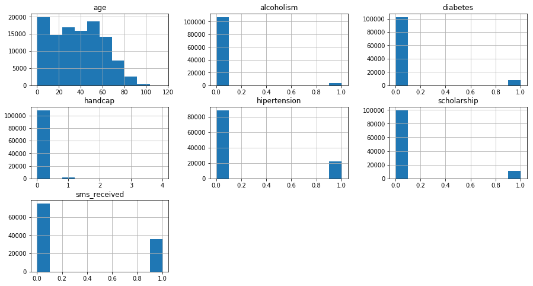

```python
#checking general relationship using histogram
df_noshow.hist(figsize=(15,8))
```

The histogram of the variables shows some observations,some observations i can make from this are;

Most patients don't have diseases such as diabetes,hipertension,alcoholism,& aren't handicapped

Most patients aren't above 60 years old

Most patients aren't part of the scholarship program and not every patients received sms as regards their appointment

So far age is the only variable whose skewed to right really makes sense.

QUESTION 1. DO MORE FEMALES IN YOUNG AGE SHOW UP MORE THAN FEMALES IN OLD AGE?

```python
female=df_noshow.loc[df_noshow['gender']=='F' ]
```

```python
age=df_noshow.loc[df_noshow['age']>=18]
```

```python
median=df_noshow.age.median()
```

```python
df_noshow.age.median()
```

```
37.0
```

```python
#select females with age less than the median
Young_female =df_noshow.query('age<37')
#select females with age greater than or equal to the median
Old_female=df_noshow.query('age>=37')

#ensure each queries included samples exactly once
num_samples=df_noshow.shape[0]
num_samples==Young_female['no_show'].count()+ Old_female['no_show'].count()
```

```
True
```

```python
Young_female.no_show.count(),Old_female.no_show.count()
```

```
(54583, 55943)
```

ensured each queries icluded the samples at once

```python
# using query to select
median=df_noshow['age'].median
Young_female=df_noshow.query('age<37')
Old_female=df_noshow.query('age>=37')
Y_f_noshow=Young_female['no_show'].count()
O_f_noshow=Old_female['no_show'].count()
```

```
Text(0,0.5,'Apperances')
```

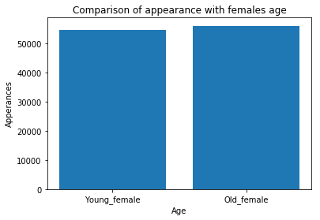

```python
# create a bar chart
locations=[1,2]
heights=[Y_f_noshow,O_f_noshow]
labels=['Young_female','Old_female' ]
plt.bar(locations,heights,tick_label=labels)
plt.title('Comparison of appearance with females age')
plt.xlabel('Age')
plt.ylabel('Apperances')
```

QUESTION 2 :IS GENDER AS A SINGLE VARIABLE RELATED TO PATIENT's SHOWING UP ?

```python
# set show up and missed variables
showed_up=df_noshow.no_show=="No"
```

```python
missed=df_noshow.no_show=="Yes"
```

```python
df_noshow.groupby('gender').mean().age
```

```
gender
F    38.894542
M    33.736863
Name: age, dtype: float64
```

```python
# select query for gender
female=df_noshow.query('age<38')
male=df_noshow.query('age>=33')
female_show=female['no_show'].count()
male_show=male['no_show'].count()
```

```
Text(0,0.5,'Appearances')
```

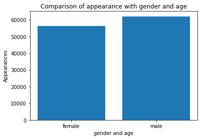

```python
#plot bar chart
locations=[1,2,]
heights=[female_show,male_show]
labels=['female','male' ]
plt.bar(locations,heights,tick_label=labels)
plt.title('Comparison of appearance with gender and age')
plt.xlabel('gender and age')
plt.ylabel('Appearances')
```

to compare gender alone as a variable to determine its significance on the patient'sattendance

I would use a stacked and unstacked bar chart to see if there is still any correlation for further visualization

To determine gender as the only variable,I would get the value by using the groupby function and then plot a stacked bar chart

```python
#total value of the gender
def showed_up(scholarship,no_show):
    total_value=df_noshow.groupby('gender')['no_show'].value_counts()
    total_value_no_show=total_value
    return total_value
```

[output not shown]

```
Text(0.5,1,'The total number of female and male who showed up')
```

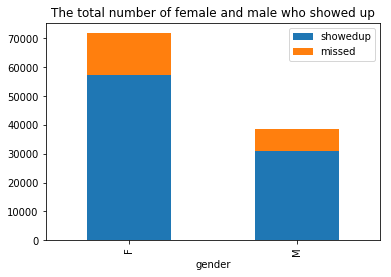

```python
# set show up and missed variables
showedup=df_noshow.no_show=="No"
missed=df_noshow.no_show=="Yes"

#plot the stacked bar chart
labels =('showedup','missed')
df_noshow.groupby('gender')['no_show'].value_counts().unstack().plot(kind='bar',stacked=True)
plt.legend(labels);
plt.title('The total number of female and male who showed up')
```

its safe to say gennder as a single variable is not enough to determine the patients appearance on their various appointments

QUESTION 3 :IS SCHOLARSHIP SIGNIFICANT IN DETERMINING PATIENTS SHOW UP?

```python
#total value of scholarship
def_total_show(scholarship,no_show):
    total_value=df_noshow.groupby('scholarship')['no_show'].value_counts()
    total_value_no_show=total_value
    return total_value_no_show
```

[output not shown]

```
Text(0.5,1,'The total number of female and male who got scholarship that showed up')
```

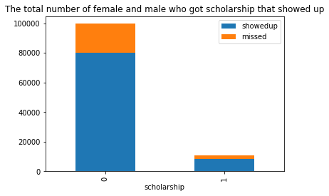

```python
# set show up and missed variables
showedup=df_noshow.no_show=="No"
missed=df_noshow.no_show=="Yes"

#plot the stacked bar chart
labels =('showedup','missed')
df_noshow.groupby('scholarship')['no_show'].value_counts().unstack().plot(kind='bar',stacked=True)
plt.legend(labels);
plt.title('The total number of female and male who got scholarship that showed up')
```

From the stacked bar chart above,it is obvious that people who didn't receive scholarship were much more than those that

received scholarship but that didn't really determine the patient's attendance because there wasn't a significant difference in

the attendance of patient's who were beneficiaries of the BOLSA FAMILIA and those who weren't beneficiaries.

its obvious that scholarship as a single variable cant't effectively determine the patient's attendance.

CONCLUSION

in determinining the patient's showing up .

variable in determining the patient's attendance

LIMITATIONS: One of the major limitations i faced was in the process of trying to drop the weird values from the 'age' column

with a negative value of 1 , another thing i observed is that if more information was provided in thisdataset,some

questions like if distance would have been a factor too or not

RESOURCES

N/A